# AdviseInvest_Analytics

Chinmay

11/10/2021

Read the csv file and put it into ‘advise_invest’

Remove rows with NAs.

Remove the row with the single outlier in num_accts. Remove the rows with negative income values.

```r
advise_invest <- read_csv("adviseinvest.csv")
advise_invest_cl<- advise_invest %>% filter(num_accts<5) %>% filter(income>0) %>% na.omit()

summary(advise_invest_cl)
```

```
##     answered          income           female             age
##  Min.   :0.0000   Min.   :  2760   Min.   :0.00000   Min.   :19.00
##  1st Qu.:0.0000   1st Qu.: 13550   1st Qu.:0.00000   1st Qu.:26.00
##  Median :1.0000   Median : 23310   Median :0.00000   Median :32.00
##  Mean   :0.5466   Mean   : 33773   Mean   :0.05417   Mean   :34.77
##  3rd Qu.:1.0000   3rd Qu.: 41690   3rd Qu.:0.00000   3rd Qu.:40.00
##  Max.   :1.0000   Max.   :159450   Max.   :1.00000   Max.   :74.00
##       job        num_dependents       rent           own_res
##  Min.   :0.000   Min.   :1.000   Min.   :0.0000   Min.   :0.0000
##  1st Qu.:2.000   1st Qu.:1.000   1st Qu.:0.0000   1st Qu.:0.0000
##  Median :2.000   Median :1.000   Median :0.0000   Median :1.0000
##  Mean   :1.915   Mean   :1.141   Mean   :0.2104   Mean   :0.6811
##  3rd Qu.:2.000   3rd Qu.:1.000   3rd Qu.:0.0000   3rd Qu.:1.0000
##  Max.   :3.000   Max.   :2.000   Max.   :1.0000   Max.   :1.0000
##     new_car          chk_acct        sav_acct        num_accts
##  Min.   :0.0000   Min.   :0.000   Min.   :0.0000   Min.   :0.000
##  1st Qu.:0.0000   1st Qu.:0.000   1st Qu.:0.0000   1st Qu.:2.000
##  Median :0.0000   Median :1.000   Median :0.0000   Median :2.000
##  Mean   :0.2408   Mean   :1.468   Mean   :0.9563   Mean   :2.345
##  3rd Qu.:0.0000   3rd Qu.:3.000   3rd Qu.:2.0000   3rd Qu.:3.000
##  Max.   :1.0000   Max.   :3.000   Max.   :4.0000   Max.   :4.000
##      mobile           product
##  Min.   :0.00000   Min.   :0.000
##  1st Qu.:0.00000   1st Qu.:0.000
##  Median :0.00000   Median :1.000
##  Mean   :0.09109   Mean   :1.536
##  3rd Qu.:0.00000   3rd Qu.:3.000
##  Max.   :1.00000   Max.   :4.000
```

Converting the 4 variables identified into factors.

```r
product <- factor(advise_invest_cl$product,ordered=TRUE)
job <- factor(advise_invest_cl$job,ordered=TRUE)

sav_acct <- factor(advise_invest_cl$sav_acct,ordered=TRUE)

chk_acct <- factor(advise_invest_cl$chk_acct,ordered=TRUE)

mean(advise_invest_cl$answered)
```

```
## [1] 0.5465948
```

Plot “answered” against “num_accts”

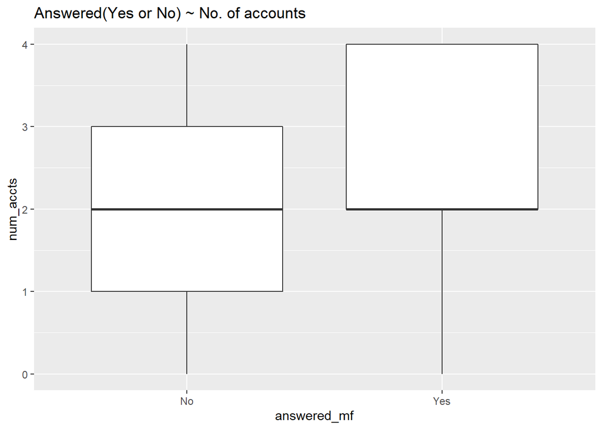

```r
answered_m <- ifelse(advise_invest_cl$answered==0,"No","Yes")

answered_mf <- factor(answered_m)
ggplot(advise_invest_cl,aes(x=answered_mf,y=num_accts)) + geom_boxplot() + labs(title = "Answered(Yes or No) ~ No. of accounts")
```

The median number of accounts for both the boxplots, for customers who answered and did not answer is 2(two). Therefore it is better to target customers who have more than 2(two) accounts that is 3 or 4 accounts. These set of customers will have a better possibility of answering the calls. Customers having less than two accounts are less likely to answer.

Barplot of the counts or proportions of customers who answered, comparing those with and without mobile phones.

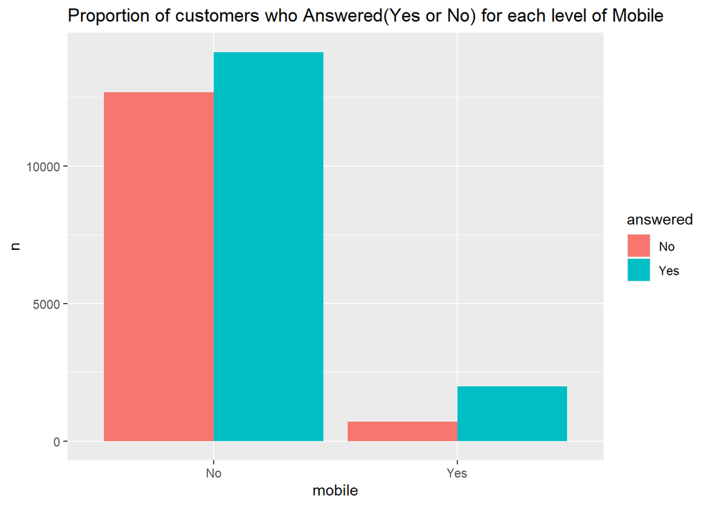

```r
advise_invest_cl %>%
  mutate(mobile=factor(mobile),
         mobile=ifelse(mobile==0,"No","Yes"),
        answered=ifelse(answered==0,"No","Yes")) %>%                    count(answered,mobile) %>%
          ggplot(aes(x=mobile,y=n,fill=answered)) +              geom_col(position="dodge") + labs(title="Proportion of customers who Answered(Yes or No) for each level of Mobile")
```

Clearly people with mobile phones answer these calls more frequently. This might be due to the fact that a mobile phone is easier to answer if the owner is carrying the phone. It would be advantageous for AdviseInvest to get cell phone numbers for all callbacks.

Now we have a rough idea on how the relationship of certain target and prospective predictor variables are

Formatting the dataset properly. According to the data dictionary and EDA the predictor variables are job, rent, checking account(chk_acct), savings account(sav_acct), own_car, new_car

```r
advise_invest <- read_csv("adviseinvest.csv")  %>%            # Download data
  select(-product) %>%                                        # Remove the product column
  na.omit %>%                                                 # Remove NAs
  filter(income > 0,                                          # Filter out mistaken data
         num_accts < 5) %>%
  mutate(answered = factor(ifelse(answered==0, "no","yes"),   # Turn answered into yes/no factor
                           levels  = c("no", "yes")),
         female = factor(female),                             # Make categorical variables into factors
         job = factor(job),
         rent = factor(rent),
         own_res = factor(own_res),
         new_car = factor(new_car),
         mobile = factor(mobile),
         chk_acct = factor(chk_acct),
         sav_acct = factor(sav_acct))
```

Fit a tree model to the outcome using just one variable, income.

```r
income_model <- rpart(formula = answered ~ income, data=advise_invest)

income_model
```

```
## n= 29499
##
## node), split, n, loss, yval, (yprob)
##       * denotes terminal node
##
##  1) root 29499 13375 yes (0.4534052 0.5465948)
##    2) income>=39135 8063  2944 no (0.6348754 0.3651246) *
##    3) income< 39135 21436  8256 yes (0.3851465 0.6148535)
##      6) income< 35625 20412  8128 yes (0.3981971 0.6018029)
##       12) income>=4295 20156  8128 yes (0.4032546 0.5967454)
##         24) income< 9595 2944  1408 no (0.5217391 0.4782609)
##           48) income>=7890 1152   256 no (0.7777778 0.2222222) *
##           49) income< 7890 1792   640 yes (0.3571429 0.6428571) *
##         25) income>=9595 17212  6592 yes (0.3829886 0.6170114) *
##       13) income< 4295 256     0 yes (0.0000000 1.0000000) *
##      7) income>=35625 1024   128 yes (0.1250000 0.8750000) *
```

```r
predict(income_model,type="class") %>% head
```

```
##   1   2   3   4   5   6
## yes yes yes yes yes yes
## Levels: no yes
```

```r
(predict(income_model,type="class")==advise_invest$answered) %>% mean
```

```
## [1] 0.6420218
```

Calculating Entropy and information gain

```r
income_model
```

```
## n= 29499
##
## node), split, n, loss, yval, (yprob)
##       * denotes terminal node
##
##  1) root 29499 13375 yes (0.4534052 0.5465948)
##    2) income>=39135 8063  2944 no (0.6348754 0.3651246) *
##    3) income< 39135 21436  8256 yes (0.3851465 0.6148535)
##      6) income< 35625 20412  8128 yes (0.3981971 0.6018029)
##       12) income>=4295 20156  8128 yes (0.4032546 0.5967454)
##         24) income< 9595 2944  1408 no (0.5217391 0.4782609)
##           48) income>=7890 1152   256 no (0.7777778 0.2222222) *
##           49) income< 7890 1792   640 yes (0.3571429 0.6428571) *
##         25) income>=9595 17212  6592 yes (0.3829886 0.6170114) *
##       13) income< 4295 256     0 yes (0.0000000 1.0000000) *
##      7) income>=35625 1024   128 yes (0.1250000 0.8750000) *
```

```r
parent_entropy <- -.45*log2(.45) - .55*log2(.55)

child1_entropy <- -.63*log2(.63) - .37*log2(.37)

child2_entropy <- -.39*log2(.39) - .61*log2(.61)

p_c1 <- 8063/29499

p_c2 <- 21436/29499

info_gain <- parent_entropy - (p_c1*child1_entropy + p_c2*child2_entropy)

info_gain
```

```
## [1] 0.03183638
```

Fit a new tree model of answered using all the predictors

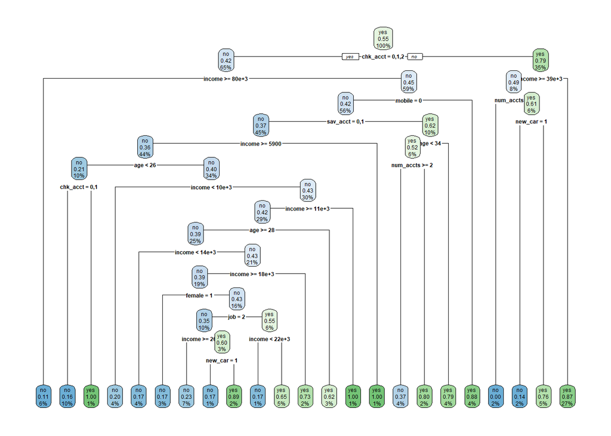

```r
tree_model <- rpart(formula=answered ~. , data=advise_invest)

rpart.plot(x=tree_model,tweak=1.7,roundint=T)
```

Accuracy of the model

```r
(predict(tree_model,type="class")==advise_invest$answered) %>% mean
```

```
## [1] 0.8199261
```

Confusion Matrix

```r
table(predicted=predict(tree_model,type="class"), observed=advise_invest$answered)
```

```
##          observed
## predicted    no   yes
##       no  10367  2304
##       yes  3008 13820
```

Profit using the confusion matrix.

```r
(cost_benefit <-  matrix(c(75, 0, -25, 0), ncol = 2,
                         dimnames = list(c("predicted yes", "no"),
                                         c("observed yes","no"))))
```

```
##               observed yes  no
## predicted yes           75 -25
## no                       0   0
```

```r
13820*75 - 3008*25
```

```
## [1] 961300
```

Profit when all customers are called. We consider this a baseline case for profit since it does not require a model. treat the customers who answer as true positives treat the customers who do not answer as false positives.

```r
advise_invest %>% count(answered)
```

```
## # A tibble: 2 x 2
##   answered     n
##   <fct>    <int>
## 1 no       13375
## 2 yes      16124
```

```r
16124*75 - 13375*25
```

```
## [1] 874925
```

Profit (revenue - costs) with the classification tree model from above using a class decision threshold of .3? (.3 is the threshold that produces maximum profit.)

Using the cost-benefit matrix provided above, but create a new confusion matrix using `predict()` with the `type = "prob"` argument. Converting the resulting probabilities into class labels using the threshold of .3. In other words, if the model-predicted probability of answering is greater than or equal to .3, then assign a label of “yes.”

```r
table(predicted=ifelse(predict(tree_model,type="prob")[,2]>=0.3,"yes","no"),observed=advise_invest$answered)
```

```
##          observed
## predicted    no   yes
##       no   9599  1856
##       yes  3776 14268
```

```r
14268*75 - 3776*25
```

```
## [1] 975700
```

The primary problem is to keep the sales representatives busy, that is they must be occupied with customers in the follow-up call. This is important as a call that is answered results in financial plan getting sold resulting in profit. It is important to determine which customers have the higher probability of answering the call.

Constructed a model that predicts customers who will answer the call. Compared the model’s output with the historical data using a confusion matrix. In simple words it is a table to compare the predicted output and the observed data.figured out that the model is 82% accurate. It means out of 100 predictions by the model 82 were right, which is a pretty good number. As per the model, if the company calls the customers who are predicted to answer then the profit is 961300 which is much higher than 874925, which would be the profit if all the customers are called. Therefore it makes sense to call the customers who are predicted to answer

The data set “prospective” contains observations for prospective customers. There is no target variable in this dataset because these customers have not yet been called.

Cleaning the dataset

```r
prospective <- read_csv("customer_data.csv") %>%
  mutate(female = factor(female),
         job = factor(job),
         rent = factor(rent),
         own_res = factor(own_res),
         new_car = factor(new_car),
         mobile = factor(mobile),
         chk_acct = factor(chk_acct),
         sav_acct = factor(sav_acct))
```

Using the supervised model to predict a probability of answering for each prospective customer.

2. Assign a predicted class label of “yes” to every customer whose model-estimated probability of answering is .3 or greater. (This is the optimal class decision threshold.)
3. Filter the dataset to contain only prospective customers with a predicted class label of “yes.” This is the contact list.

```r
lst <- prospective %>% select(customer_id) %>% mutate(prob=predict(tree_model,newdata=prospective,type="class"))
head(lst)
```

```
## # A tibble: 6 x 2
##   customer_id prob
##   <chr>       <fct>
## 1 H1597       no
## 2 P1446       no
## 3 E1492       no
## 4 W5143       yes
## 5 W4927       yes
## 6 M6161       yes
```

Assigning a predicted class label of “yes” to every customer whose model-estimated probability of answering is .3 or greater. (This is the optimal class decision threshold.) and Filtering the dataset to contain only prospective customers with a predicted class label of “yes.” Or those customers predicted probability of answering is .3 or greater.

```r
ans_prob <- predict(tree_model,newdata=prospective, type="prob")[,2]>=0.3

contact_lst <- lst %>% filter(ans_prob>=0.3)

contact_lst
```

```
## # A tibble: 624 x 2
##    customer_id prob
##    <chr>       <fct>
##  1 W5143       yes
##  2 W4927       yes
##  3 M6161       yes
##  4 U4472       yes
##  5 H557        yes
##  6 B54         yes
##  7 L2217       yes
##  8 M8502       yes
##  9 E5979       yes
## 10 N6079       yes
## # ... with 614 more rows
```

```r
count(contact_lst)
```

```
## # A tibble: 1 x 1
##       n
##   <int>
## 1   624
```

Applied the model on new data set of prospective customers and put a constraint in the model that only those customers will answer who have a probability of answering than 30%. 624 customers who will answer the call . Therefore the company must target these set of customers and put them on priority as they will answer the call which will ultimately result in the sale getting completed and hence will result in profit.